# EDA Report On World Value Survey Data

10/20/2019

## Introduction to WVS

## Introduction to WVS

The World Values Survey (www.worldvaluessurvey.org) is a global network of social scientists studying changing values and their impact on social and political life.

The survey, which started in 1981, seeks to use the most rigorous, high-quality research designs in each country. The WVS consists of nationally representative surveys conducted in almost 100 countries which contain almost 90 percent of the world’s population, using a common questionnaire. The WVS is the largest non-commercial, cross-national, time series investigation of human beliefs and values ever executed, currently including interviews with almost 400,000 respondents. Moreover the WVS is the only academic study covering the full range of global variations, from very poor to very rich countries, in all of the world’s major cultural zones.

## Introduction to Data

## Introduction to Data

I choose the latest public WVS data (V20180912), which is the Wave 6 that carried out during 2010 to 2014. Raw data consists of 89565 0bservations and 440 variables, containing the survey result cross over 50 countries. According to the questionaire provided along the data, variables named after V250 provided information that is not related to world value.

## Data Cleaning Process

## Data Cleaning Process

I take the first step of data cleaning as Missing Value Analysis, missing value in questionaire data can be a complacate situation, because the cause of missing value of can be various, whether the respondent do not want to answer, do not know how to answer, and so on, luckily according to the description of the survey data, it tells us that different cause of missing value were coded into different numbers, such as -1 represents do not know, -2 represents no answer, -3 represents not applicable. For simplicity, we treat all kinds of negtive value as missing. First we need to obtain a big picture of the distribution of missing values.

## Data Cleaning Process

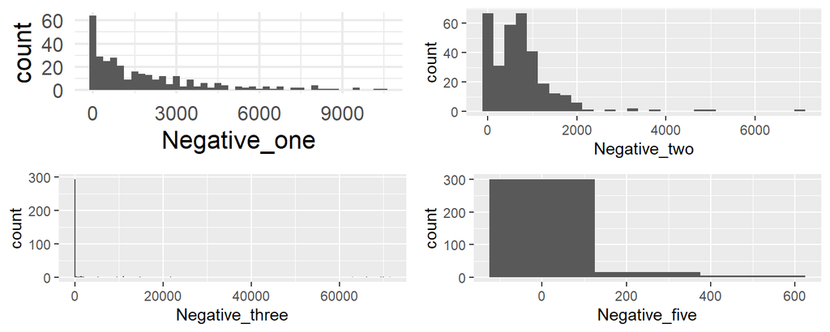

Above histgram show the distribution of different types of missing value over all the variables, we can see that, for missing value type -1, most of the variables have less than 3000 missing values, for all four types of missing value, -1 is the most “popular” one.

## Data Cleaning Process

Now we want to solve the problem by deleting missing values, we can choose to delete vatiables or delete observations, for here we choose to delete variables containing a large portion of missing values, than delete observations containing a large portion of missing values.

## Data Cleaning Process

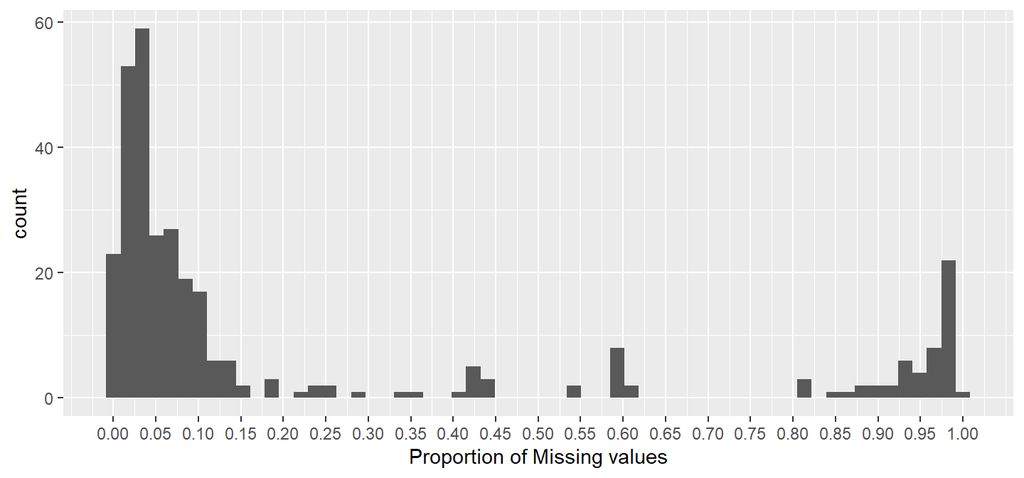

We can see that most of variables have less than 10% missing values, so we choose to delete all that variables containing more than 10% missing values, then we delete observations containing missing values.

## Data Cleaning Process

After solving the missing value problem, we still have 18445 observations and 215 variables.

## EDA Process

## EDA Process

- V2: Country Code
- V4: How important is family? 1 to 4 represents very important, rather important, not very important and not at all important.
- V5: How important is friends? 1 to 4 represents very important, rather important, not very important and not at all important.
- V6: How important is leisure time? 1 to 4 represents very important, rather important, not very important and not at all important.
- V7: How important is politics? 1 to 4 represents very important, rather important, not very important and not at all important.

## EDA Process

- V8: How important is work? 1 to 4 represents very important, rather important, not very important and not at all important.
- V9: How important is religion? 1 to 4 represents very important, rather important, not very important and not at all important.
- V10: How happy the respondent is? 1 to 4 represents very happy, rather happy, not very happy and not at all happy.

## Cross Table Analysis

One important way to analyze questionaire data is to do cross analysis, for example as the variables V4 and V10, we can analyze how many people who thinks family is important is happy about their life:

Cross Analysis (Freqency)

| V10 | V4=1 | V4=2 | V4=3 | V4=4 |
| --- | --- | --- | --- | --- |
| 1 | 7421 | 166 | 33 | 4 |
| 2 | 7974 | 473 | 42 | 5 |
| 3 | 1802 | 166 | 23 | 4 |
| 4 | 303 | 22 | 3 | 4 |

## Cross Table Analysis

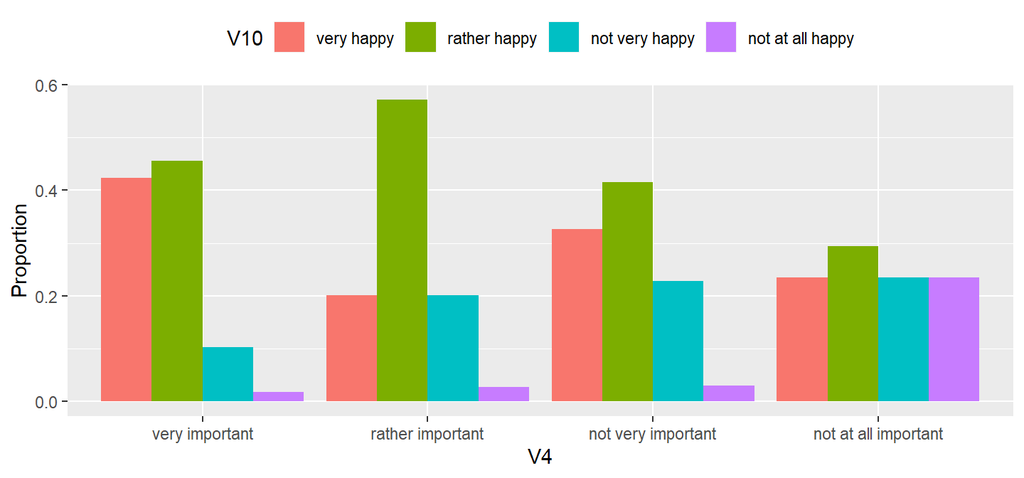

## Factor Analysis

## Factor Analysis

Even after the data clening process, the number of variables decreased from 440 to 215, there are still too many variables, so further more, we choose to use Factor Analysis to reduce the number of variables.

Before we do factor analysis we have to calculate the covariance matrix, When Calculating covariance matrix, I got the warning message that some of the standard diviation is 0, which means some variables have only one unique value, so we have to delete those variables.

```
## Warning in cor(da[, 2:215]): the standard deviation is zero
```

## Factor Analysis

Besides the unique values problem, after reading the article of Jon Starkweather (Factor Analysis with Binary items: A quick review with examples), due to the fact that my data has some binary variables, we have to use special function to calculate the covariance matrix to guarantee R will calculate the right covariance matrix.

Another problem I encounted is that the data set is too big to be processed by my laptop when calculating the covariance matrix, so I have to draw samples from the whole dataset.

## Factor Analysis

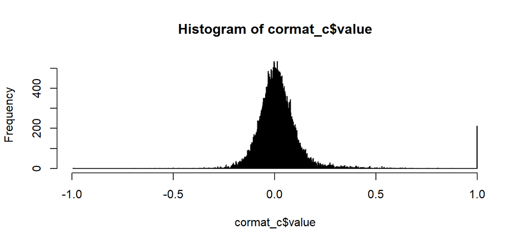

Above is the Histgram of the correlation coefficients, we canconclude that most of the variables have no correlation with other variables.

## Factor Analysis

As the first step of factor analysis, we have to decide the number of factors, we use parallel analysis to determine to factors.

### Factor Analysis

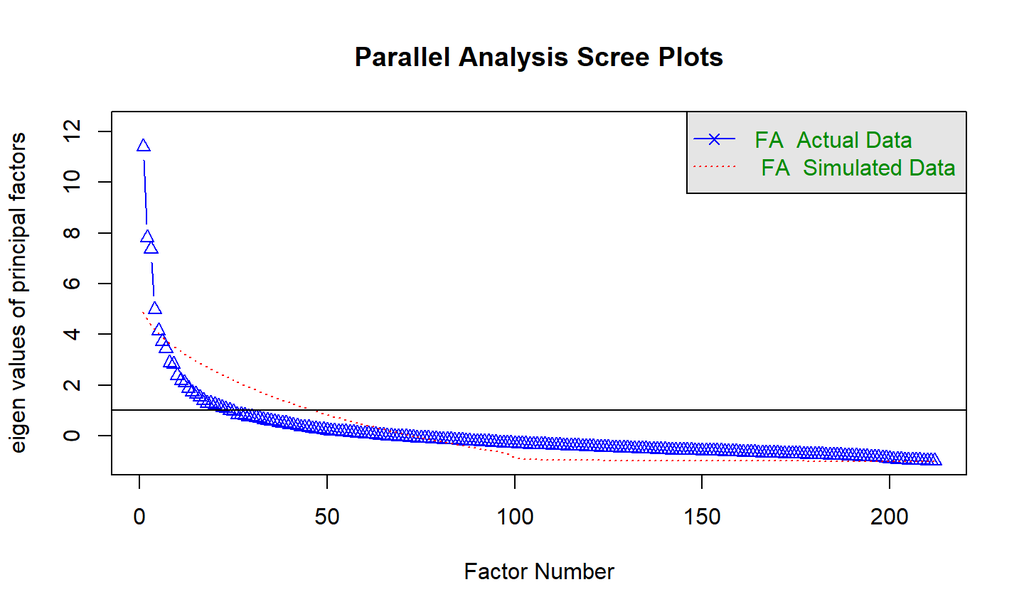

```
## Parallel analysis suggests that the number of factors =  5  and the number of components =  NA
```

## Factor Analysis

Part of the result of factor analysis is shown below:

Part of result of Factor Analysis

|  | Country Code | Factor 1 | Factor 2 | Factor 3 | Factor 4 | Factor 5 | Factor 6 |
| --- | --- | --- | --- | --- | --- | --- | --- |
| 2231 | 51 | -328.74 | 237.28 | 304.33 | 55.29 | -465.40 | -1316.88 |
| 2232 | 51 | -331.61 | 241.08 | 313.51 | 58.68 | -470.38 | -1309.25 |
| 2233 | 51 | -341.54 | 244.68 | 319.73 | 58.91 | -484.77 | -1366.33 |
| 2234 | 51 | -330.80 | 258.81 | 313.71 | 64.71 | -479.52 | -1363.52 |
| 2240 | 51 | -320.87 | 227.74 | 297.60 | 54.81 | -453.92 | -1268.17 |
| 2243 | 51 | -329.05 | 250.65 | 314.08 | 58.93 | -470.26 | -1332.08 |

## Cluster Analysis

## Cluster Analysis

Same as factor analysis, the first step of cluster analysis is to determine the number of clusters, we can determine through observing the change of SSE, if k is smaller than the real number of clusters, as k increase, the SSE will decrease significantly, but once k exceed the real number of clusters, the decrease of SSE will be smaller, so the plot of SSE will contains a obvious turning point.

## Cluster Analysis

\[SSE = \sum_{i=1}^{k} \sum_{p_j\in C_i}^{} \|p_j-m_i\|_2^2\]

- \(C_i\) is the \(i_{th}\) cluster
- \(m_i\) is the center of the \(i_{th}\) cluster
- \(\|p_j-m_i\|_2^2\) is the Euclidian Distance between \(C_i\) and \(m_i\)

## Cluster Analysis

Another important fact about k-means is that this algorithm will randomly decide k initial point as the center of each cluster, so the final result of k-means may varies, so for each k, we do several times of clustering, and take the average of SSE of experiments with same k value as the real SSE for coresponding k value.

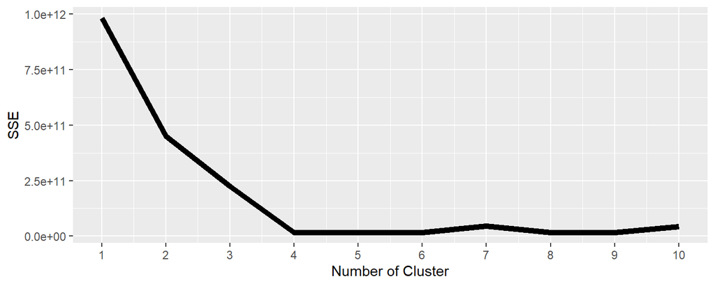

## Cluster Analysis

According to SEE plot, the real k value should be 4. So now we set the k value as 4 and do several times of clustering and record the one with smallest SSE.

After clustering, we can do more analysis on the data, bolow is the cluster in each countries:

### Cluster Analysis

| Country Code | Number of People | Cluster 1 | Cluster 2 | Cluster 3 | Cluster 4 |
| --- | --- | --- | --- | --- | --- |
| 484 | 1402 | 0 | 0 | 0 | 1402 |
| 566 | 1269 | 0 | 147 | 0 | 1122 |
| 840 | 1110 | 0 | 0 | 0 | 1110 |
| 458 | 1062 | 0 | 0 | 0 | 1062 |
| 710 | 1144 | 0 | 0 | 227 | 917 |
| 716 | 800 | 0 | 0 | 0 | 800 |
| 288 | 1249 | 483 | 0 | 0 | 766 |
| 398 | 753 | 0 | 0 | 0 | 753 |

### Cluster Analysis

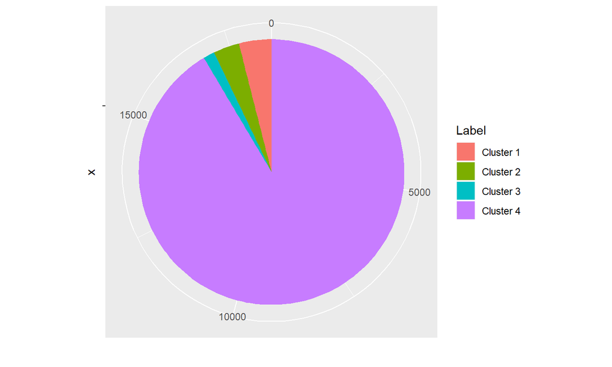